# Task 2: Experimentation and uplift testing

Yixi Deng

7/23/2021

## Load required libraries and datasets

```r
#### Load the required libraries
library(data.table)
library(stringr)
library(lubridate)
library(tidyverse)
library(modelr)
library(knitr)
library(rpart)
library(dplyr)

#### Load the dataset
filePath <- "C:/Users/User/Desktop/JobSeeking/Project/Forage/ANZ/"
transactionData <- fread(paste0(filePath,"ANZ synthesised transaction dataset.csv"))
```

## Identify the annual salary for each customer

### Examining transaction data

We can use `str()` to look at the format of each column and see a sample of data.

```r
str(transactionData)
```

```
## Classes 'data.table' and 'data.frame':   12043 obs. of  23 variables:
##  $ status           : chr  "authorized" "authorized" "authorized" "authorized" ...
##  $ card_present_flag: int  1 0 1 1 1 NA 1 1 1 NA ...
##  $ bpay_biller_code : chr  "" "" "" "" ...
##  $ account          : chr  "ACC-1598451071" "ACC-1598451071" "ACC-1222300524" "ACC-1037050564" ...
##  $ currency         : chr  "AUD" "AUD" "AUD" "AUD" ...
##  $ long_lat         : chr  "153.41 -27.95" "153.41 -27.95" "151.23 -33.94" "153.10 -27.66" ...
##  $ txn_description  : chr  "POS" "SALES-POS" "POS" "SALES-POS" ...
##  $ merchant_id      : chr  "81c48296-73be-44a7-befa-d053f48ce7cd" "830a451c-316e-4a6a-bf25-e37caedca49e" "835c231d-8cdf-4e96-859d-e9d571760cf0" "48514682-c78a-4a88-b0da-2d6302e64673" ...
##  $ merchant_code    : int  NA NA NA NA NA NA NA NA NA NA ...
##  $ first_name       : chr  "Diana" "Diana" "Michael" "Rhonda" ...
##  $ balance          : num  35.39 21.2 5.71 2117.22 17.95 ...
##  $ date             : chr  "8/1/2018" "8/1/2018" "8/1/2018" "8/1/2018" ...
##  $ gender           : chr  "F" "F" "M" "F" ...
##  $ age              : int  26 26 38 40 26 20 43 43 27 40 ...
##  $ merchant_suburb  : chr  "Ashmore" "Sydney" "Sydney" "Buderim" ...
##  $ merchant_state   : chr  "QLD" "NSW" "NSW" "QLD" ...
##  $ extraction       : POSIXct, format: "2018-08-01 01:01:15" "2018-08-01 01:13:45" ...
##  $ amount           : num  16.25 14.19 6.42 40.9 3.25 ...
##  $ transaction_id   : chr  "a623070bfead4541a6b0fff8a09e706c" "13270a2a902145da9db4c951e04b51b9" "feb79e7ecd7048a5a36ec889d1a94270" "2698170da3704fd981b15e64a006079e" ...
##  $ country          : chr  "Australia" "Australia" "Australia" "Australia" ...
##  $ customer_id      : chr  "CUS-2487424745" "CUS-2487424745" "CUS-2142601169" "CUS-1614226872" ...
##  $ merchant_long_lat: chr  "153.38 -27.99" "151.21 -33.87" "151.21 -33.87" "153.05 -26.68" ...
##  $ movement         : chr  "debit" "debit" "debit" "debit" ...
##  - attr(*, ".internal.selfref")=<externalptr>
```

### Change the format for some variables

```r
#### Convert status column to a factor format
transactionData$status <- as.factor(transactionData$status)
#### Convert date column to a date format
transactionData$date <- as.Date(transactionData$date, format = "%m/%d/%Y")
#### Convert gender column to a factor format
transactionData$gender <- as.factor(transactionData$gender)
#### Convert merchant_state column to a factor format
transactionData$merchant_state <- as.factor(transactionData$merchant_state)
#### Convert movement column to a factor format
transactionData$movement <- as.factor(transactionData$movement)
str(transactionData)
```

```
## Classes 'data.table' and 'data.frame':   12043 obs. of  23 variables:
##  $ status           : Factor w/ 2 levels "authorized","posted": 1 1 1 1 1 2 1 1 1 2 ...
##  $ card_present_flag: int  1 0 1 1 1 NA 1 1 1 NA ...
##  $ bpay_biller_code : chr  "" "" "" "" ...
##  $ account          : chr  "ACC-1598451071" "ACC-1598451071" "ACC-1222300524" "ACC-1037050564" ...
##  $ currency         : chr  "AUD" "AUD" "AUD" "AUD" ...
##  $ long_lat         : chr  "153.41 -27.95" "153.41 -27.95" "151.23 -33.94" "153.10 -27.66" ...
##  $ txn_description  : chr  "POS" "SALES-POS" "POS" "SALES-POS" ...
##  $ merchant_id      : chr  "81c48296-73be-44a7-befa-d053f48ce7cd" "830a451c-316e-4a6a-bf25-e37caedca49e" "835c231d-8cdf-4e96-859d-e9d571760cf0" "48514682-c78a-4a88-b0da-2d6302e64673" ...
##  $ merchant_code    : int  NA NA NA NA NA NA NA NA NA NA ...
##  $ first_name       : chr  "Diana" "Diana" "Michael" "Rhonda" ...
##  $ balance          : num  35.39 21.2 5.71 2117.22 17.95 ...
##  $ date             : Date, format: "2018-08-01" "2018-08-01" ...
##  $ gender           : Factor w/ 2 levels "F","M": 1 1 2 1 1 2 1 1 1 2 ...
##  $ age              : int  26 26 38 40 26 20 43 43 27 40 ...
##  $ merchant_suburb  : chr  "Ashmore" "Sydney" "Sydney" "Buderim" ...
##  $ merchant_state   : Factor w/ 9 levels "","ACT","NSW",..: 5 3 3 5 5 1 8 8 9 1 ...
##  $ extraction       : POSIXct, format: "2018-08-01 01:01:15" "2018-08-01 01:13:45" ...
##  $ amount           : num  16.25 14.19 6.42 40.9 3.25 ...
##  $ transaction_id   : chr  "a623070bfead4541a6b0fff8a09e706c" "13270a2a902145da9db4c951e04b51b9" "feb79e7ecd7048a5a36ec889d1a94270" "2698170da3704fd981b15e64a006079e" ...
##  $ country          : chr  "Australia" "Australia" "Australia" "Australia" ...
##  $ customer_id      : chr  "CUS-2487424745" "CUS-2487424745" "CUS-2142601169" "CUS-1614226872" ...
##  $ merchant_long_lat: chr  "153.38 -27.99" "151.21 -33.87" "151.21 -33.87" "153.05 -26.68" ...
##  $ movement         : Factor w/ 2 levels "credit","debit": 2 2 2 2 2 2 2 2 2 2 ...
##  - attr(*, ".internal.selfref")=<externalptr>
```

### Create weekly salary data frame

```r
salary_week_df <- transactionData[movement == "credit",
                                  c("account", "date", "amount", "movement")]
salary_week_df <- salary_week_df %>% group_by(account) %>%
                  summarise(avg_week_salary = mean(amount))
head(salary_week_df)
```

| account | avg_week_salary |
| --- | --- |
| ACC-1037050564 | 892.09 |
| ACC-1056639002 | 3195.01 |
| ACC-1199531521 | 3785.78 |
| ACC-1217063613 | 4863.62 |
| ACC-1222300524 | 1002.13 |
| ACC-1243371644 | 1681.58 |

We created a `salary` dataframe with unique account id and the average weekly salary, which we found from the credit movement.

### Create annual salary data frame

```r
salary_annual_df <- cbind(salary_week_df,annual_salary = salary_week_df$avg_week_salary*52)
head(salary_annual_df)
```

|  | account | avg_week_salary | annual_salary |
| --- | --- | --- | --- |
| 1 | ACC-1037050564 | 892.09 | 46388.68 |
| 2 | ACC-1056639002 | 3195.01 | 166140.52 |
| 3 | ACC-1199531521 | 3785.78 | 196860.56 |
| 4 | ACC-1217063613 | 4863.62 | 252908.24 |
| 5 | ACC-1222300524 | 1002.13 | 52110.76 |
| 6 | ACC-1243371644 | 1681.58 | 87442.16 |

Then, we got the annual salary by timing the weekly salary with 52, for there are 52 weeks in a year.

## Explore correlations between annual salary and various customer attributes

### Create a new transactionData dataframe with annual salary

```r
transactionData1 <- merge(transactionData,salary_annual_df[,-2], by = "account")
str(transactionData1)
```

```
## Classes 'data.table' and 'data.frame':   12043 obs. of  24 variables:
##  $ account          : chr  "ACC-1037050564" "ACC-1037050564" "ACC-1037050564" "ACC-1037050564" ...
##  $ status           : Factor w/ 2 levels "authorized","posted": 1 1 2 1 1 1 1 1 1 1 ...
##  $ card_present_flag: int  1 1 NA 1 1 1 1 1 1 1 ...
##  $ bpay_biller_code : chr  "" "" "" "" ...
##  $ currency         : chr  "AUD" "AUD" "AUD" "AUD" ...
##  $ long_lat         : chr  "153.10 -27.66" "153.10 -27.66" "153.10 -27.66" "153.10 -27.66" ...
##  $ txn_description  : chr  "SALES-POS" "POS" "PAYMENT" "SALES-POS" ...
##  $ merchant_id      : chr  "48514682-c78a-4a88-b0da-2d6302e64673" "02d45834-6f65-4f52-9a33-0b242dd7a078" "" "1ab3e343-3775-4d54-9dac-2b0834500025" ...
##  $ merchant_code    : int  NA NA NA NA NA NA NA NA NA NA ...
##  $ first_name       : chr  "Rhonda" "Rhonda" "Rhonda" "Rhonda" ...
##  $ balance          : num  2117 2072 2040 2029 1964 ...
##  $ date             : Date, format: "2018-08-01" "2018-08-01" ...
##  $ gender           : Factor w/ 2 levels "F","M": 1 1 1 1 1 1 1 1 1 1 ...
##  $ age              : int  40 40 40 40 40 40 40 40 40 40 ...
##  $ merchant_suburb  : chr  "Buderim" "North Lakes" "" "Port Macquarie" ...
##  $ merchant_state   : Factor w/ 9 levels "","ACT","NSW",..: 5 5 1 3 5 5 9 5 3 5 ...
##  $ extraction       : POSIXct, format: "2018-08-01 01:38:45" "2018-08-01 09:15:03" ...
##  $ amount           : num  40.9 45.1 32 11.1 65.1 ...
##  $ transaction_id   : chr  "2698170da3704fd981b15e64a006079e" "ad101b96b9d44b968b2519e2bb26a649" "94622881419c44e1b799a52d82572207" "353c30ef66e345059a22305b36f138a2" ...
##  $ country          : chr  "Australia" "Australia" "Australia" "Australia" ...
##  $ customer_id      : chr  "CUS-1614226872" "CUS-1614226872" "CUS-1614226872" "CUS-1614226872" ...
##  $ merchant_long_lat: chr  "153.05 -26.68" "152.99 -27.21" "" "152.92 -31.43" ...
##  $ movement         : Factor w/ 2 levels "credit","debit": 2 2 2 2 2 2 2 2 2 2 ...
##  $ annual_salary    : num  46389 46389 46389 46389 46389 ...
##  - attr(*, ".internal.selfref")=<externalptr>
##  - attr(*, "sorted")= chr "account"
```

We updated the transaction dataframe with the annual salary found the last section. And then, we began to explore the corrleations between annual salary and other customer attributes.

### Explore correlations between annual salary and age

```r
cor(transactionData1$annual_salary, transactionData1$age)
```

```
## [1] -0.0838749
```

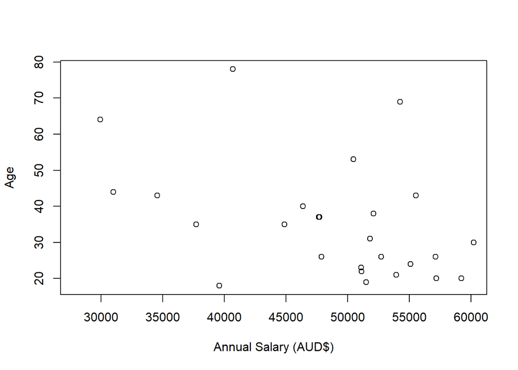

```r
plot(transactionData1$annual_salary, transactionData1$age,
     xlab = "Annual Salary (AUD$)",
     ylab = "Age",
     xlim = c(28000,60000))
lines(predict(lm(transactionData1$annual_salary~transactionData1$age)),col = "blue") #? trendline
```

A weak negative correlation exists between `age` and `annual_salary`.

### Explore correlations between annual salary and gender

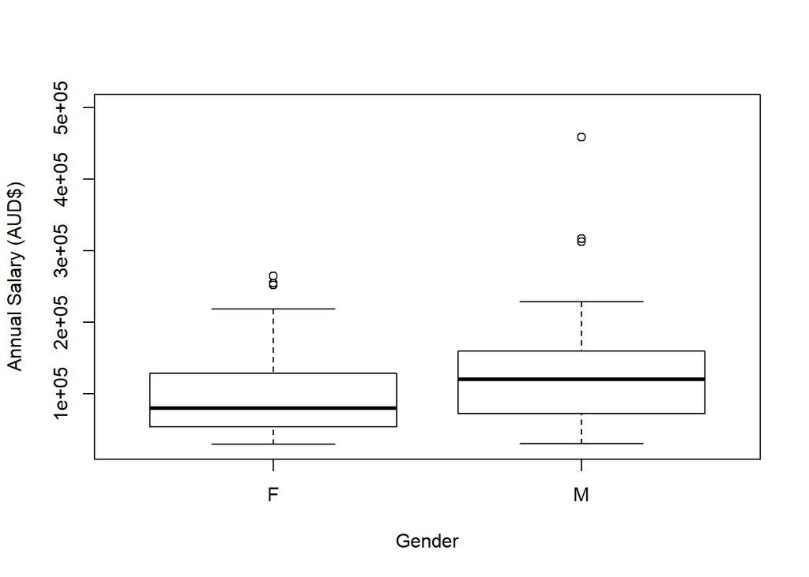

```r
### Scatter plot
plot(transactionData1$gender,transactionData1$annual_salary,
      xlab = "Gender",
      ylab = "Annual Salary (AUD$)",
      ylim = c(28000,500000))
```

```r
### Chi-squared test for annual salary and gender
chisq.test(transactionData1$annual_salary, transactionData1$gender, correct = FALSE)
```

```
##
##  Pearson's Chi-squared test
##
## data:  transactionData1$annual_salary and transactionData1$gender
## X-squared = 12043, df = 99, p-value < 2.2e-16
```

### Explore correlations between annual salary and states

```r
account_loc_inf <- transactionData1[match(unique(transactionData$account),
                                          transactionData1$account), c("account","long_lat")]
account_loc_inf$long <- as.numeric(substr(account_loc_inf$long_lat,1,6))
account_loc_inf$lat <- as.numeric(substr(account_loc_inf$long_lat,8,13))
```

```r
coords_state <- function(coords_state, loc_inf,var_name,state_name){
        var_name <- ifelse(loc_inf$long <= coords_state[[1]][3] &
                                 loc_inf$long >= coords_state[[1]][1] &
                                 loc_inf$lat <=  coords_state[[1]][4] &
                                 loc_inf$lat >= coords_state[[1]][2],
                                 state_name,var_name)
}
```

```r
coords_NSW <- as.data.frame(c(140.9993, -37.50503, 153.6299, -28.15703 ),
                            c("xmin","ymin","xmax","ymax"))
coords_VIC <- as.data.frame(c(140.9617, -39.13396, 149.9763, -33.99605 ),
                            c("xmin","ymin","xmax","ymax"))
coords_QLD <- as.data.frame(c(137.9943, -29.17719, 153.5522, -9.229287 ),
                            c("xmin","ymin","xmax","ymax"))
coords_SA <- as.data.frame(c(129.0013, -38.06, 141.003, -25.99638 ),
                           c("xmin","ymin","xmax","ymax"))
coords_WA <- as.data.frame(c(112.9211, -35.12228, 129.0019, -13.74142 ),
                           c("xmin","ymin","xmax","ymax"))
coords_TAS <- as.data.frame(c(143.8353, -43.63203, 148.4472, -39.45196 ),
                            c("xmin","ymin","xmax","ymax"))
coords_NT <- as.data.frame(c(129.0005, -25.99862, 137.9991, -10.97392 ),
                           c("xmin","ymin","xmax","ymax"))
coords_ACT <- as.data.frame(c(148.7628, -148.7628, 149.3972, -35.12442 ),
                            c("xmin","ymin","xmax","ymax"))
```

```r
account_loc_inf$state <- NA

account_loc_inf$state <- coords_state(coords_NSW, account_loc_inf,
                                      account_loc_inf$state, "NSW")
account_loc_inf$state <- coords_state(coords_VIC, account_loc_inf,
                                      account_loc_inf$state, "VIC")
account_loc_inf$state <- coords_state(coords_QLD, account_loc_inf,
                                      account_loc_inf$state, "QLD")
account_loc_inf$state <- coords_state(coords_SA, account_loc_inf,
                                      account_loc_inf$state,"SA")
account_loc_inf$state <- coords_state(coords_WA, account_loc_inf,
                                      account_loc_inf$state, "WA")
account_loc_inf$state <- coords_state(coords_TAS, account_loc_inf,
                                      account_loc_inf$state, "TAS")
account_loc_inf$state <- coords_state(coords_NT, account_loc_inf,
                                      account_loc_inf$state, "NT")
account_loc_inf$state <- coords_state(coords_ACT, account_loc_inf,
                                      account_loc_inf$state, "ACT")

head(account_loc_inf)
```

| account | long_lat | long | lat | state |
| --- | --- | --- | --- | --- |
| ACC-1598451071 | 153.41 -27.95 | 153.41 | -27.95 | QLD |
| ACC-1222300524 | 151.23 -33.94 | 151.23 | -33.94 | NSW |
| ACC-1037050564 | 153.10 -27.66 | 153.10 | -27.66 | QLD |
| ACC-1608363396 | 151.22 -33.87 | 151.22 | -33.87 | NSW |
| ACC-2776252858 | 144.95 -37.76 | 144.95 | -37.76 | VIC |
| ACC-182446574 | 116.06 -32.00 | 116.06 | -32.00 | WA |

```r
#### Create a new transactionData with state variable
transactionData2 <- merge(transactionData1,account_loc_inf[,c(1,5)],by = "account")
```

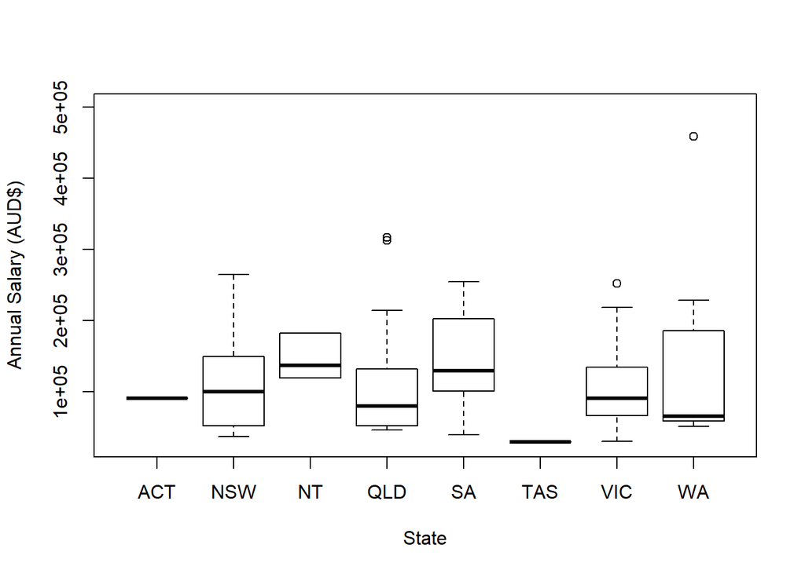

```r
transactionData2$state <- as.factor(transactionData2$state)

### Scatter plot
plot(transactionData2$state,transactionData2$annual_salary,
      xlab = "State",
      ylab = "Annual Salary (AUD$)",
      ylim = c(28000,500000))
```

```r
### Chi-squared test for annual salary and state
chisq.test(transactionData2$annual_salary, transactionData2$state, correct = FALSE)
```

```
##
##  Pearson's Chi-squared test
##
## data:  transactionData2$annual_salary and transactionData2$state
## X-squared = 83440, df = 686, p-value < 2.2e-16
```

We have a high chi-squared and a p-value of less than 0.05 signifance level, so we reject the null hypothesis and conclude that `state` and `annual_salary` have a significant relationship.

Now, let’s build simple regression models based on the selected attributes.

## Build a Simple Regression Model

### Build a simple regression model to predict the annual salary for each customer

```r
model1 <-  annual_salary ~ age + gender
summary(lm(formula = model1, data = transactionData2))
```

```
##
## Call:
## lm(formula = model1, data = transactionData2)
##
## Residuals:
##    Min     1Q Median     3Q    Max
## -92917 -53637 -12854  32641 333039
##
## Coefficients:
##             Estimate Std. Error t value Pr(>|t|)
## (Intercept) 123144.2     2186.9  56.311   <2e-16 ***
## age           -626.4       64.8  -9.667   <2e-16 ***
## genderM      28344.4     1303.2  21.750   <2e-16 ***
## ---
## Signif. codes:  0 '***' 0.001 '**' 0.01 '*' 0.05 '.' 0.1 ' ' 1
##
## Residual standard error: 71430 on 12040 degrees of freedom
## Multiple R-squared:  0.04457,    Adjusted R-squared:  0.04442
## F-statistic: 280.9 on 2 and 12040 DF,  p-value: < 2.2e-16
```

The p-values of all attributes in model1 are less than 0.05; however, the R-squared is too small to show it is an accurate model.

```r
model2 <-  annual_salary ~ age + gender + state
summary(lm(formula = model2, data = transactionData2))
```

```
##
## Call:
## lm(formula = model2, data = transactionData2)
##
## Residuals:
##     Min      1Q  Median      3Q     Max
## -102448  -49412  -12313   35770  317533
##
## Coefficients:
##              Estimate Std. Error t value Pr(>|t|)
## (Intercept)  70212.80   11483.86   6.114 1.00e-09 ***
## age           -303.45      68.02  -4.461 8.23e-06 ***
## genderM      33938.28    1332.93  25.461  < 2e-16 ***
## stateNSW     36312.85   11179.16   3.248 0.001164 **
## stateNT      86812.25   11735.79   7.397 1.48e-13 ***
## stateQLD     40849.39   11190.35   3.650 0.000263 ***
## stateSA      77286.55   11393.03   6.784 1.23e-11 ***
## stateTAS    -20839.91   13486.84  -1.545 0.122324
## stateVIC     25763.97   11145.27   2.312 0.020814 *
## stateWA      49925.10   11242.96   4.441 9.05e-06 ***
## ---
## Signif. codes:  0 '***' 0.001 '**' 0.01 '*' 0.05 '.' 0.1 ' ' 1
##
## Residual standard error: 69910 on 11910 degrees of freedom
##   (123 observations deleted due to missingness)
## Multiple R-squared:  0.08949,    Adjusted R-squared:  0.0888
## F-statistic: 130.1 on 9 and 11910 DF,  p-value: < 2.2e-16
```

## Build a Decision-Tree Model

### Data partition

```r
set.seed(123)
ind <- sample(2, nrow(transactionData2), replace = T , prob =  c(0.5,0.5))
train <- transactionData2[ind == 1, ]
test <- transactionData2[ind == 2, ]
### Tree Classification
tree1 <- rpart(model1, data = train)
tree2 <- rpart(model2, data = train)
```

### Prediction and Accuarcy

```r
### Prediction
p1 <- predict(tree1, train)
### Root Mean Square Error
sqrt(mean(train$annual_salary - p1)^2)
```

```
## [1] 5.801124e-11
```

```r
### R Square
(cor(train$annual_salary,p1))^2
```

```
## [1] 0.4380375
```

```r
### Prediction
p2 <- predict(tree2, train)
### Root Mean Square Error
sqrt(mean(train$annual_salary - p2)^2)
```

```
## [1] 8.736721e-11
```

```r
### R Square
(cor(train$annual_salary,p2))^2
```

```
## [1] 0.7847837
```

Overall, the decision-tree models have much higher accuracy than the simple regression models have.

The decision-tree model with model2 has the higher accuracy compared to the decision-tree model with model1. As a result, we would recommend the decision-tree model with model2 as our final model for prediction.